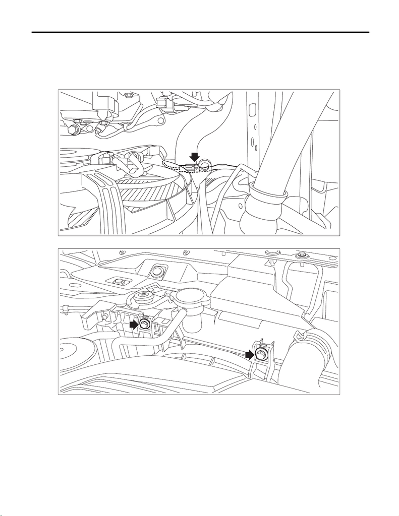

CO(w/o STI)-46

Radiator Main Fan and Fan Motor

COOLING

9. Radiator Main Fan and Fan Motor

A: REMOVAL

1) Disconnect the ground terminal from battery sensor. <Ref. to NT-5, BATTERY, NOTE, Note.>

2) Remove the reservoir tank. <Ref. to CO(w/o STI)-52, REMOVAL, Reservoir Tank.>

3) Disconnect the connector from the main fan motor.

4) Remove the bolts which secure the radiator main fan motor assembly onto the radiator.

5) Remove the radiator main fan motor assembly from the vehicle.

B: INSTALLATION

Install in the reverse order of removal.

Tightening torque:

7.5 N·m (0.8 kgf-m, 5.5 ft-lb)

CO-03220

CO-03362

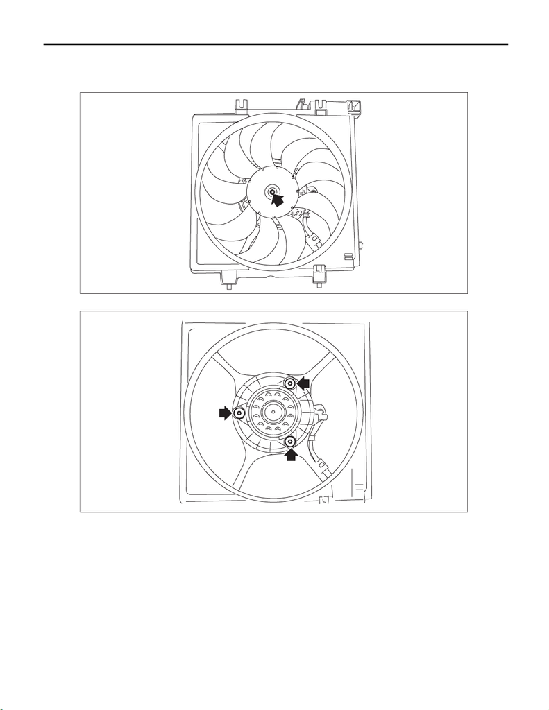

CO(w/o STI)-47

Radiator Main Fan and Fan Motor

COOLING

C: DISASSEMBLY

1) Remove the clip which holds the main fan motor connector onto the radiator main fan shroud.

2) Disconnect the radiator main fan from the main fan motor.

3) Disconnect the main fan motor from the radiator main fan shroud.

CO-02870

CO-02871

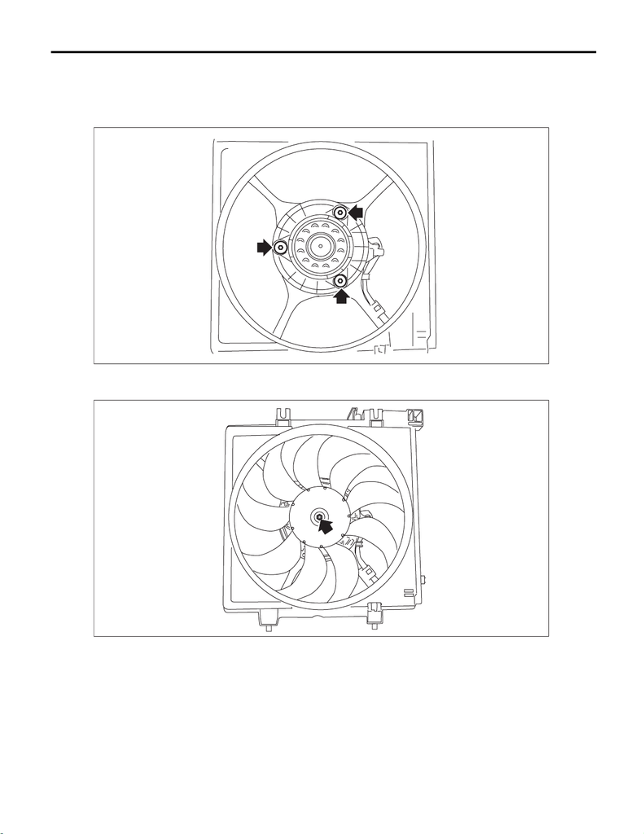

CO(w/o STI)-48

Radiator Main Fan and Fan Motor

COOLING

D: ASSEMBLY

Assemble in the reverse order of disassembly.

Tightening torque:

4.41 N·m (0.45 kgf-m, 3.25 ft-lb)

Tightening torque:

3.4 N·m (0.3 kgf-m, 2.5 ft-lb)

E: INSPECTION

Check that the radiator main fan, radiator main fan shroud and main fan motor do not have deformation,

cracks or damage.

CO-02871

CO-02870